# Traffic Accidents in San Francisco

Federal, state, and local governments have started making more of their data publicly available. This is part of the so-called open data movement. Application Programming Interfaces (APIs), which many institutions have begun supporting, allow researchers and other individuals interested in working with and analyzing data to access information, often large amounts of it, programmatically.

[DataSF](https://data.sfgov.org/) is the open data portal for the city (and county) of San Francisco.

## Extract

Using the requests module, we access the API with the SFPD data. We specify, using the limit parameter, the maximum number of records that should be returned. It is important to read the API documentation for information on limits, appropriate uses, and the various available options. The documentation for this specific data source can be found [here](http://dev.socrata.com/foundry/#/data.sfgov.org/tmnf-yvry). It is important to note that this data is updated daily, so your results will vary.

The data will be returned in a format known as [JSON](http://www.json.org/), which stands for JavaScript Object Notation, and will be stored in an object called response. Depending on your connection, this may take a few minutes.

```python
import requests, json, pandas as pd
url = 'http://data.sfgov.org/resource/tmnf-yvry.json?$limit=50000'
response = requests.get(url)
```

## Load

Now that the raw data is in the response variable, we can load it into a Pandas DataFrame. Here, we use json.loads() to get it in the proper format.

```python
data = json.loads(response.text)
df = pd.DataFrame(data)
```

```python
df
```

|  | address | category | date | dayofweek | descript | incidntnum | location | pddistrict | resolution | time | x | y |
| --- | --- | --- | --- | --- | --- | --- | --- | --- | --- | --- | --- | --- |
| 0 | 900.0 Block of HARRISON ST | NON-CRIMINAL | 1412208000 | Thursday | LOST PROPERTY | 146205499 | {u'latitude': u'37.7775833632336', u'needs_rec... | SOUTHERN | NONE | 13:00 | -122.403876552366 | 37.7775833632336 |
| 1 | 2300.0 Block of SAN BRUNO AV | VEHICLE THEFT | 1414022400 | Thursday | STOLEN TRUCK | 140900108 | {u'latitude': u'37.7335714048034', u'needs_rec... | BAYVIEW | NONE | 20:00 | -122.406306152069 | 37.7335714048034 |
| 2 | 800.0 Block of MARKET ST | BURGLARY | 1412985600 | Saturday | BURGLARY, UNLAWFUL ENTRY | 140859561 | {u'latitude': u'37.7847532835996', u'needs_rec... | SOUTHERN | ARREST, BOOKED | 11:24 | -122.407036790381 | 37.7847532835996 |
| 3 | 800.0 Block of BRYANT ST | NON-CRIMINAL | 1414195200 | Saturday | LOST PROPERTY | 146234658 | {u'latitude': u'37.7752316978411', u'needs_rec... | SOUTHERN | NONE | 11:45 | -122.403742962696 | 37.7752316978411 |
| 4 | LAKE MERCED BL / BROTHERHOOD WAY | LARCENY/THEFT | 1415232000 | Thursday | GRAND THEFT FROM LOCKED AUTO | 146232997 | {u'latitude': u'37.7146945276069', u'needs_rec... | TARAVAL | NONE | 14:59 | -122.485226315294 | 37.7146945276069 |
| 5 | CALIFORNIA ST / DAVIS ST | ASSAULT | 1413504000 | Friday | AGGRAVATED ASSAULT WITH BODILY FORCE | 140879462 | {u'latitude': u'37.7935081014216', u'needs_rec... | CENTRAL | NONE | 15:40 | -122.397613296977 | 37.7935081014216 |
| 6 | 1000.0 Block of POTRERO AV | SUSPICIOUS OCC | 1410134400 | Monday | SUSPICIOUS OCCURRENCE | 140757802 | {u'latitude': u'37.7568256145719', u'needs_rec... | MISSION | NONE | 17:10 | -122.406656623063 | 37.7568256145719 |
| 7 | 2000.0 Block of MISSION ST | OTHER OFFENSES | 1411776000 | Saturday | POSSESSION OF BURGLARY TOOLS | 140817036 | {u'latitude': u'37.7639057653745', u'needs_rec... | MISSION | ARREST, BOOKED | 21:15 | -122.419519291984 | 37.7639057653745 |
| 8 | CORTLAND AV / BAY SHORE BL | SUSPICIOUS OCC | 1411948800 | Monday | SUSPICIOUS OCCURRENCE | 140821645 | {u'latitude': u'37.7395669609406', u'needs_rec... | BAYVIEW | NONE | 16:31 | -122.406979507963 | 37.7395669609406 |
| 9 | 25TH ST / FOLSOM ST | VEHICLE THEFT | 1412812800 | Thursday | STOLEN AUTOMOBILE | 140859395 | {u'latitude': u'37.7509035118498', u'needs_rec... | MISSION | NONE | 19:30 | -122.413926655862 | 37.7509035118498 |
| 10 | 1800.0 Block of SUTTER ST | LARCENY/THEFT | 1413936000 | Wednesday | PETTY THEFT OF PROPERTY | 146218806 | {u'latitude': u'37.7865328905614', u'needs_rec... | NORTHERN | NONE | 18:00 | -122.430010289844 | 37.7865328905614 |
| 11 | 800.0 Block of BRYANT ST | DRUG/NARCOTIC | 1411689600 | Friday | POSSESSION OF MARIJUANA FOR SALES | 140812462 | {u'latitude': u'37.7752316978411', u'needs_rec... | SOUTHERN | NONE | 13:47 | -122.403742962696 | 37.7752316978411 |
| 12 | 0.0 Block of 4TH ST | NON-CRIMINAL | 1414108800 | Friday | LOST PROPERTY | 146235361 | {u'latitude': u'37.7850408915497', u'needs_rec... | SOUTHERN | NONE | 11:45 | -122.405020936706 | 37.7850408915497 |
| 13 | 1900.0 Block of BUCHANAN ST | VEHICLE THEFT | 1413331200 | Wednesday | STOLEN AUTOMOBILE | 140881912 | {u'latitude': u'37.7875021119303', u'needs_rec... | NORTHERN | NONE | 22:30 | -122.430043028044 | 37.7875021119303 |
| 14 | CLAYTON ST / TWINPEAKS BL | ARSON | 1409788800 | Thursday | ARSON | 140743613 | {u'latitude': u'37.7610072307552', u'needs_rec... | PARK | NONE | 01:13 | -122.446434498728 | 37.7610072307552 |
| 15 | 200.0 Block of JONES ST | NON-CRIMINAL | 1409702400 | Wednesday | AIDED CASE | 140741184 | {u'latitude': u'37.7830494562119', u'needs_rec... | TENDERLOIN | NONE | 10:30 | -122.412465977545 | 37.7830494562119 |
| 16 | SUTTER ST / STOCKTON ST | LARCENY/THEFT | 1411603200 | Thursday | PETTY THEFT FROM LOCKED AUTO | 140810676 | {u'latitude': u'37.7894347630337', u'needs_rec... | CENTRAL | NONE | 15:00 | -122.406958660602 | 37.7894347630337 |
| 17 | HAYES ST / STANYAN ST | LARCENY/THEFT | 1409529600 | Monday | GRAND THEFT FROM UNLOCKED AUTO | 146179838 | {u'latitude': u'37.7728951613702', u'needs_rec... | PARK | NONE | 22:34 | -122.454286690265 | 37.7728951613702 |
| 18 | GEARY BL / STEINER ST | LARCENY/THEFT | 1409616000 | Tuesday | PETTY THEFT OF PROPERTY | 140741015 | {u'latitude': u'37.7841504916183', u'needs_rec... | NORTHERN | NONE | 20:00 | -122.4345637373 | 37.7841504916183 |
| 19 | 600.0 Block of LEAVENWORTH ST | VEHICLE THEFT | 1416009600 | Saturday | STOLEN AUTOMOBILE | 140967136 | {u'latitude': u'37.7869348074983', u'needs_rec... | CENTRAL | NONE | 03:48 | -122.414935774638 | 37.7869348074983 |
| 20 | 400.0 Block of BAY ST | ASSAULT | 1410566400 | Saturday | CHILD ABUSE (PHYSICAL) | 140772725 | {u'latitude': u'37.8054746066172', u'needs_rec... | CENTRAL | NONE | 15:40 | -122.414501928254 | 37.8054746066172 |
| 21 | BUSH ST / WEBSTER ST | LARCENY/THEFT | 1411084800 | Friday | PETTY THEFT FROM LOCKED AUTO | 140789560 | {u'latitude': u'37.7872308879586', u'needs_rec... | NORTHERN | NONE | 00:30 | -122.431816136158 | 37.7872308879586 |
| 22 | 1300.0 Block of 30TH AV | BURGLARY | 1412726400 | Wednesday | BURGLARY OF RESIDENCE, FORCIBLE ENTRY | 140912313 | {u'latitude': u'37.7628319123172', u'needs_rec... | TARAVAL | NONE | 09:00 | -122.488852509457 | 37.7628319123172 |
| 23 | 200.0 Block of KING ST | LARCENY/THEFT | 1414972800 | Monday | GRAND THEFT FROM PERSON | 140932690 | {u'latitude': u'37.7764328521786', u'needs_rec... | SOUTHERN | NONE | 18:45 | -122.394098177073 | 37.7764328521786 |
| 24 | 14TH AV / MORAGA ST | VANDALISM | 1409616000 | Tuesday | MALICIOUS MISCHIEF, VANDALISM OF VEHICLES | 140739327 | {u'latitude': u'37.7563445000784', u'needs_rec... | TARAVAL | NONE | 09:30 | -122.470967156063 | 37.7563445000784 |
| 25 | 700.0 Block of KEARNY ST | LARCENY/THEFT | 1415318400 | Friday | GRAND THEFT FROM A BUILDING | 140944996 | {u'latitude': u'37.7950029644549', u'needs_rec... | CENTRAL | NONE | 16:00 | -122.404861643051 | 37.7950029644549 |
| 26 | STOCKTON ST / SUTTER ST | LARCENY/THEFT | 1415491200 | Sunday | GRAND THEFT FROM PERSON | 140949736 | {u'latitude': u'37.7894347630337', u'needs_rec... | CENTRAL | NONE | 12:40 | -122.406958660602 | 37.7894347630337 |
| 27 | MARKET ST / 11TH ST | VEHICLE THEFT | 1412553600 | Monday | STOLEN MOTORCYCLE | 140844885 | {u'latitude': u'37.7755894130348', u'needs_rec... | SOUTHERN | NONE | 08:15 | -122.418698328939 | 37.7755894130348 |
| 28 | 1600.0 Block of WALLACE AV | MISSING PERSON | 1410480000 | Friday | FOUND PERSON | 140770666 | {u'latitude': u'37.727516075789', u'needs_reco... | BAYVIEW | LOCATED | 20:15 | -122.391415328578 | 37.727516075789 |
| 29 | BOSWORTH ST / ROUSSEAU ST | ROBBERY | 1415836800 | Thursday | ROBBERY ON THE STREET, STRONGARM | 140961489 | {u'latitude': u'37.7333118541647', u'needs_rec... | INGLESIDE | NONE | 09:30 | -122.430279612614 | 37.7333118541647 |
| ... | ... | ... | ... | ... | ... | ... | ... | ... | ... | ... | ... | ... |
| 26374 | WILLOW ST / POLK ST | VEHICLE THEFT | 1414281600 | Sunday | STOLEN TRUCK | 140908817 | {u'latitude': u'37.7835680535504', u'needs_rec... | NORTHERN | NONE | 23:00 | -122.419274801449 | 37.7835680535504 |
| 26375 | SUNSET BL / NORIEGA ST | NON-CRIMINAL | 1414713600 | Friday | FOUND PROPERTY | 140922287 | {u'latitude': u'37.7534118534114', u'needs_rec... | TARAVAL | NONE | 10:27 | -122.495225044311 | 37.7534118534114 |
| 26376 | 500.0 Block of CARTER ST | MISSING PERSON | 1414022400 | Thursday | MISSING JUVENILE | 140907411 | {u'latitude': u'37.7085268833154', u'needs_rec... | INGLESIDE | NONE | 19:30 | -122.423827920239 | 37.7085268833154 |
| 26377 | MARKET ST / JONES ST | ROBBERY | 1414886400 | Sunday | ROBBERY, BODILY FORCE | 140940621 | {u'latitude': u'37.7809039697055', u'needs_rec... | SOUTHERN | NONE | 15:30 | -122.411979487494 | 37.7809039697055 |
| 26378 | 400.0 Block of 7TH ST | OTHER OFFENSES | 1410825600 | Tuesday | TRAFFIC VIOLATION | 140779492 | {u'latitude': u'37.7749623956038', u'needs_rec... | SOUTHERN | NONE | 01:00 | -122.405411882091 | 37.7749623956038 |
| 26379 | 900.0 Block of HARRISON ST | LARCENY/THEFT | 1410739200 | Monday | GRAND THEFT FROM PERSON | 140776573 | {u'latitude': u'37.7778758664587', u'needs_rec... | SOUTHERN | NONE | 02:20 | -122.403369341832 | 37.7778758664587 |
| 26380 | 200.0 Block of OFARRELL ST | OTHER OFFENSES | 1413072000 | Sunday | MISCELLANEOUS INVESTIGATION | 140867354 | {u'latitude': u'37.7862782769118', u'needs_rec... | TENDERLOIN | NONE | 01:00 | -122.408814633856 | 37.7862782769118 |
| 26381 | 600.0 Block of EDDY ST | LARCENY/THEFT | 1410825600 | Tuesday | GRAND THEFT FROM LOCKED AUTO | 140780994 | {u'latitude': u'37.7832989144971', u'needs_rec... | NORTHERN | NONE | 13:30 | -122.417889157912 | 37.7832989144971 |
| 26382 | 100.0 Block of CAMERON WY | NON-CRIMINAL | 1411344000 | Monday | AIDED CASE, MENTAL DISTURBED | 140801788 | {u'latitude': u'37.7207809778816', u'needs_rec... | BAYVIEW | PSYCHOPATHIC CASE | 12:30 | -122.386906562606 | 37.7207809778816 |
| 26383 | 100.0 Block of MASON ST | LARCENY/THEFT | 1415491200 | Sunday | GRAND THEFT FROM LOCKED AUTO | 146234608 | {u'latitude': u'37.7845792034875', u'needs_rec... | TENDERLOIN | NONE | 21:00 | -122.409401966956 | 37.7845792034875 |
| 26384 | 700.0 Block of GEARY ST | LARCENY/THEFT | 1410825600 | Tuesday | GRAND THEFT BICYCLE | 140790642 | {u'latitude': u'37.7862871732137', u'needs_rec... | CENTRAL | NONE | 17:00 | -122.416355393687 | 37.7862871732137 |
| 26385 | 200.0 Block of KING ST | NON-CRIMINAL | 1415145600 | Wednesday | AIDED CASE, DOG BITE | 140938591 | {u'latitude': u'37.7770884941977', u'needs_rec... | SOUTHERN | NONE | 19:48 | -122.393248740719 | 37.7770884941977 |
| 26386 | 100.0 Block of NOE ST | LARCENY/THEFT | 1411689600 | Friday | PETTY THEFT OF PROPERTY | 140816044 | {u'latitude': u'37.7672518492254', u'needs_rec... | PARK | NONE | 10:30 | -122.433431744037 | 37.7672518492254 |
| 26387 | 2100.0 Block of GOLDEN GATE AV | LARCENY/THEFT | 1412294400 | Friday | GRAND THEFT FROM LOCKED AUTO | 146205041 | {u'latitude': u'37.7775919355915', u'needs_rec... | PARK | NONE | 20:00 | -122.446579550068 | 37.7775919355915 |
| 26388 | 100.0 Block of APTOS AV | ASSAULT | 1412035200 | Tuesday | BATTERY | 140826849 | {u'latitude': u'37.7302147819889', u'needs_rec... | TARAVAL | NONE | 10:11 | -122.466263433574 | 37.7302147819889 |
| 26389 | 300.0 Block of SANSOME ST | BURGLARY | 1413244800 | Tuesday | BURGLARY, FORCIBLE ENTRY | 140869849 | {u'latitude': u'37.7936628536958', u'needs_rec... | CENTRAL | NONE | 16:00 | -122.401209811207 | 37.7936628536958 |
| 26390 | ANZA ST / 10TH AV | ASSAULT | 1412553600 | Monday | AGGRAVATED ASSAULT WITH A DEADLY WEAPON | 140843417 | {u'latitude': u'37.7788954624522', u'needs_rec... | RICHMOND | NONE | 14:15 | -122.468426587712 | 37.7788954624522 |
| 26391 | 18TH ST / VALENCIA ST | ROBBERY | 1413244800 | Tuesday | ROBBERY, BODILY FORCE | 140871703 | {u'latitude': u'37.7617007179814', u'needs_rec... | MISSION | NONE | 11:17 | -122.42158168137 | 37.7617007179814 |
| 26392 | GEARY BL / WEBSTER ST | OTHER OFFENSES | 1414886400 | Sunday | LOST/STOLEN LICENSE PLATE | 140928906 | {u'latitude': u'37.7845681170633', u'needs_rec... | NORTHERN | NONE | 09:30 | -122.431206932079 | 37.7845681170633 |
| 26393 | HAYES ST / LAGUNA ST | LARCENY/THEFT | 1411430400 | Tuesday | PETTY THEFT OF PROPERTY | 146199331 | {u'latitude': u'37.7764631429439', u'needs_rec... | NORTHERN | NONE | 20:45 | -122.426265334521 | 37.7764631429439 |
| 26394 | 200.0 Block of 6TH ST | LARCENY/THEFT | 1409788800 | Thursday | PETTY THEFT FROM LOCKED AUTO | 140747897 | {u'latitude': u'37.7793934090507', u'needs_rec... | SOUTHERN | NONE | 14:00 | -122.406668854041 | 37.7793934090507 |
| 26395 | 1000.0 Block of MISSION ST | VANDALISM | 1411516800 | Wednesday | MALICIOUS MISCHIEF, VANDALISM OF VEHICLES | 140805263 | {u'latitude': u'37.780538483028', u'needs_reco... | SOUTHERN | NONE | 05:00 | -122.409198533233 | 37.780538483028 |
| 26396 | 2000.0 Block of MARKET ST | ASSAULT | 1413504000 | Friday | BATTERY | 140879246 | {u'latitude': u'37.7691618402243', u'needs_rec... | MISSION | NONE | 15:10 | -122.426893114012 | 37.7691618402243 |
| 26397 | 0.0 Block of BRADY ST | WARRANTS | 1412380800 | Saturday | WARRANT ARREST | 140835721 | {u'latitude': u'37.7725522501384', u'needs_rec... | SOUTHERN | ARREST, BOOKED | 04:00 | -122.420053263143 | 37.7725522501384 |
| 26398 | 0.0 Block of MONTGOMERY ST | BURGLARY | 1412899200 | Friday | BURGLARY,STORE UNDER CONSTRUCTION, FORCIBLE ENTRY | 140858030 | {u'latitude': u'37.7893117469688', u'needs_rec... | CENTRAL | NONE | 19:00 | -122.402168088575 | 37.7893117469688 |
| 26399 | 1300.0 Block of MISSION ST | SEX OFFENSES, FORCIBLE | 1415318400 | Friday | FORCIBLE RAPE, BODILY FORCE | 140953680 | {u'latitude': u'37.776202624796', u'needs_reco... | SOUTHERN | NONE | 22:45 | -122.414690237245 | 37.776202624796 |
| 26400 | 800.0 Block of GEARY ST | WARRANTS | 1415404800 | Saturday | WARRANT ARREST | 140947326 | {u'latitude': u'37.7860790733126', u'needs_rec... | CENTRAL | ARREST, BOOKED | 15:45 | -122.417994352344 | 37.7860790733126 |
| 26401 | 1500.0 Block of SUNNYDALE AV | ASSAULT | 1414886400 | Sunday | INFLICT INJURY ON COHABITEE | 140927522 | {u'latitude': u'37.7119166759701', u'needs_rec... | INGLESIDE | NONE | 00:50 | -122.416147813865 | 37.7119166759701 |
| 26402 | 1800.0 Block of POWELL ST | WARRANTS | 1414713600 | Friday | ENROUTE TO ADULT AUTHORITY | 140922340 | {u'latitude': u'37.8014737363544', u'needs_rec... | CENTRAL | ARREST, BOOKED | 09:00 | -122.411125687811 | 37.8014737363544 |
| 26403 | 1000.0 Block of MARKET ST | SEX OFFENSES, FORCIBLE | 1414108800 | Friday | SEXUAL BATTERY | 140912567 | {u'latitude': u'37.7816258614751', u'needs_rec... | SOUTHERN | NONE | 15:00 | -122.411002140916 | 37.7816258614751 |

26404 rows × 12 columns

This DataFrame includes information on the location, time, type of incident, and the police department district that responded.

## Transform

In this section, we want to begin processing the data so that it's in a standardized format that we can use.

### Date

First, we transform the values in the included date variable to a Python date. While the documentation is not clear on the type of data that is returned (this might also depend on the access method), it looks like the values represent the number of seconds since the epoch, which is "the point where time starts." On Unix-based systems, such as the one I'm currently on, the epoch is January 1, 1970. For more information on times in Python, see: [Time access and conversions](https://docs.python.org/2/library/time.html).

The way to determine the epoch on your system is to use the .gmtime() method in the time module. For an example, see below.

```python
import time

time.gmtime(0)
```

```
time.struct_time(tm_year=1970, tm_mon=1, tm_mday=1, tm_hour=0, tm_min=0, tm_sec=0, tm_wday=3, tm_yday=1, tm_isdst=0)
```

Use the .fromtimestamp() method to create a date variable from the number of seconds since the epoch.

```python
import datetime

df['real_date'] = df['date'].map(lambda x: datetime.date.fromtimestamp(x))
```

### Time

Because the values in the time variable are in a string format with the hours and seconds separated by a colon (:), we split on that value and create a time object.

```python
df['real_time'] = df['time'].map(lambda x: datetime.time(int(x.split(':')[0]), int(x.split(':')[1])))
```

### Lowercase

Here, we convert data to lowercase, where possible. We use the try and except approach because not all columns are of type string and, thus, cannot be converted to lowercase.

```python
for col in df.columns:
    try:
        df[col] = df[col].map(lambda x: x.lower())
    except:
        pass
```

### Traffic Filter

In this section, we create a new DataFrame for all traffic incidents. If the description column contains the word "traffic," we use it. Because the values in the location column are of type dict and because its values are already represented in separate variables in the DataFrame, we drop the column. By default, each row keeps its original index. This results in non-sequential numbering of the index values. So, we want to reset them.

```python
traffic = df[df['descript'].str.contains("traffic")]
del traffic['location']
traffic = traffic.drop_duplicates().reset_index(drop=True)
```

```python
traffic
```

|  | address | category | date | dayofweek | descript | incidntnum | pddistrict | resolution | time | x | y | real_date | real_time |
| --- | --- | --- | --- | --- | --- | --- | --- | --- | --- | --- | --- | --- | --- |
| 0 | mission st / pope st | other offenses | 1410739200 | monday | traffic violation | 140777800 | ingleside | none | 13:10 | -122.441800386053 | 37.7154294159173 | 2014-09-14 | 13:10:00 |
| 1 | capp st / 20th st | other offenses | 1410998400 | thursday | traffic violation arrest | 140788415 | mission | arrest, booked | 19:56 | -122.41796448376 | 37.7586968166786 | 2014-09-17 | 19:56:00 |
| 2 | 200.0 block of stcharles av | other offenses | 1410307200 | wednesday | traffic violation arrest | 140764976 | taraval | arrest, booked | 23:07 | -122.469238092022 | 37.7099130855206 | 2014-09-09 | 23:07:00 |
| 3 | ridgewood av / hearst av | other offenses | 1412899200 | friday | traffic violation | 140855616 | ingleside | none | 08:33 | -122.45340810993 | 37.7306726588748 | 2014-10-09 | 08:33:00 |
| 4 | excelsior av / london st | other offenses | 1413417600 | thursday | traffic violation arrest | 140877397 | ingleside | arrest, booked | 23:35 | -122.432856568129 | 37.7258720830037 | 2014-10-15 | 23:35:00 |
| 5 | martin luther king jr dr / crossover dr | other offenses | 1410048000 | sunday | traffic violation | 140754820 | richmond | none | 20:07 | -122.47736353874 | 37.7660604768749 | 2014-09-06 | 20:07:00 |
| 6 | bryant st / 6th st | other offenses | 1411257600 | sunday | traffic violation | 140798094 | southern | arrest, cited | 23:56 | -122.402527594665 | 37.7760382838642 | 2014-09-20 | 23:56:00 |
| 7 | california st / 17th av | other offenses | 1409529600 | monday | traffic violation arrest | 140736408 | richmond | arrest, cited | 19:15 | -122.476436219833 | 37.7842690832606 | 2014-08-31 | 19:15:00 |
| 8 | 19th av / sloat bl | other offenses | 1412121600 | wednesday | traffic violation | 140827433 | taraval | arrest, cited | 13:20 | -122.475102006298 | 37.7346237083866 | 2014-09-30 | 13:20:00 |
| 9 | california st / maple st | other offenses | 1414713600 | friday | traffic violation | 140923821 | richmond | arrest, cited | 19:32 | -122.455052379833 | 37.7862078479432 | 2014-10-30 | 19:32:00 |
| 10 | 3rd st / newcomb av | other offenses | 1410652800 | sunday | traffic violation arrest | 140775848 | bayview | arrest, booked | 19:16 | -122.390416955474 | 37.7355926106158 | 2014-09-13 | 19:16:00 |
| 11 | 4400.0 block of mission st | other offenses | 1415404800 | saturday | traffic violation arrest | 140946077 | ingleside | arrest, booked | 05:20 | -122.432954114381 | 37.7271871916999 | 2014-11-07 | 05:20:00 |
| 12 | san jose av / ocean av | other offenses | 1412985600 | saturday | traffic violation | 140858961 | ingleside | arrest, cited | 09:30 | -122.444746663003 | 37.7229679041421 | 2014-10-10 | 09:30:00 |
| 13 | capp st / 21st st | other offenses | 1415404800 | saturday | traffic violation arrest | 140948120 | mission | arrest, booked | 20:10 | -122.417812558787 | 37.7571005796725 | 2014-11-07 | 20:10:00 |
| 14 | hayes st / octavia st | other offenses | 1414454400 | tuesday | traffic violation arrest | 140911713 | northern | arrest, booked | 03:22 | -122.424623480779 | 37.776674002552 | 2014-10-27 | 03:22:00 |
| 15 | mcallister st / polk st | other offenses | 1414540800 | wednesday | traffic violation | 140916478 | northern | arrest, booked | 14:48 | -122.418600974625 | 37.7802607511488 | 2014-10-28 | 14:48:00 |
| 16 | 800.0 block of bryant st | other offenses | 1412294400 | friday | traffic violation | 140833537 | southern | arrest, cited | 12:30 | -122.403742962696 | 37.7752316978411 | 2014-10-02 | 12:30:00 |
| 17 | 900.0 block of market st | non-criminal | 1411171200 | saturday | traffic accident | 140793389 | southern | arrest, cited | 14:30 | -122.410243678703 | 37.782222702064 | 2014-09-19 | 14:30:00 |
| 18 | tunnel av / bay shore bl | other offenses | 1413590400 | saturday | traffic violation arrest | 140882045 | ingleside | arrest, booked | 14:25 | -122.400659850547 | 37.713059586034 | 2014-10-17 | 14:25:00 |
| 19 | golden gate av / leavenworth st | other offenses | 1412208000 | thursday | traffic violation arrest | 140831036 | tenderloin | arrest, cited | 15:54 | -122.413869632554 | 37.7818621883318 | 2014-10-01 | 15:54:00 |
| 20 | 700.0 block of capp st | other offenses | 1413849600 | tuesday | traffic violation | 140890979 | mission | arrest, booked | 13:22 | -122.417503523627 | 37.7553109114236 | 2014-10-20 | 13:22:00 |
| 21 | 800.0 block of bryant st | other offenses | 1410307200 | wednesday | traffic violation | 140764396 | southern | arrest, booked | 18:30 | -122.403742962696 | 37.7752316978411 | 2014-09-09 | 18:30:00 |
| 22 | 15th st / mission st | other offenses | 1414108800 | friday | traffic violation arrest | 140899307 | mission | arrest, booked | 00:02 | -122.419827929961 | 37.7666737552132 | 2014-10-23 | 00:02:00 |
| 23 | masonic av / hayes st | other offenses | 1415232000 | thursday | traffic violation | 140940392 | park | arrest, cited | 12:30 | -122.446091525499 | 37.773934479513 | 2014-11-05 | 12:30:00 |
| 24 | bay st / kearny st | other offenses | 1413676800 | sunday | traffic violation | 140885538 | central | arrest, cited | 20:30 | -122.407149304657 | 37.8064267317086 | 2014-10-18 | 20:30:00 |
| 25 | 3rd st / hollister av | other offenses | 1415404800 | saturday | traffic violation | 140948506 | bayview | arrest, booked | 23:45 | -122.395946406663 | 37.721716954309 | 2014-11-07 | 23:45:00 |
| 26 | taylor st / turk st | other offenses | 1415232000 | thursday | traffic violation arrest | 140939771 | tenderloin | arrest, booked | 09:09 | -122.410768766343 | 37.7832145190309 | 2014-11-05 | 09:09:00 |
| 27 | post st / stockton st | other offenses | 1412294400 | friday | traffic violation arrest | 140834381 | central | arrest, cited | 17:25 | -122.406775392392 | 37.7884982866444 | 2014-10-02 | 17:25:00 |
| 28 | 600.0 block of keith st | other offenses | 1411516800 | wednesday | traffic violation | 140806346 | bayview | arrest, cited | 13:27 | -122.382874729751 | 37.7371644263129 | 2014-09-23 | 13:27:00 |
| 29 | parkpresidio bl / fulton st | other offenses | 1410134400 | monday | traffic violation | 140758264 | richmond | arrest, cited | 00:20 | -122.471762293486 | 37.7731370564753 | 2014-09-07 | 00:20:00 |
| ... | ... | ... | ... | ... | ... | ... | ... | ... | ... | ... | ... | ... | ... |
| 580 | 3900.0 block of cesar chavez st | other offenses | 1414540800 | wednesday | traffic violation arrest | 140920021 | mission | arrest, booked | 18:00 | -122.427253391744 | 37.7477934623372 | 2014-10-28 | 18:00:00 |
| 581 | france av / paris st | other offenses | 1415232000 | thursday | traffic violation | 140941776 | ingleside | arrest, booked | 19:49 | -122.43675507464 | 37.7192703128739 | 2014-11-05 | 19:49:00 |
| 582 | valencia st / duboce av | other offenses | 1413849600 | tuesday | traffic violation arrest | 140891654 | mission | arrest, booked | 16:41 | -122.422367409563 | 37.7698682392752 | 2014-10-20 | 16:41:00 |
| 583 | alabama st / montcalm st | other offenses | 1413504000 | friday | traffic violation | 140880124 | ingleside | juvenile booked | 20:39 | -122.410499537086 | 37.7455724045589 | 2014-10-16 | 20:39:00 |
| 584 | gough st / bush st | other offenses | 1410393600 | thursday | traffic violation | 140766148 | northern | none | 13:00 | -122.425237254245 | 37.7880691746724 | 2014-09-10 | 13:00:00 |
| 585 | 19th av / ocean av | other offenses | 1413676800 | sunday | traffic violation | 140883695 | taraval | arrest, cited | 03:31 | -122.474954469109 | 37.7324560758732 | 2014-10-18 | 03:31:00 |
| 586 | haight st / buchanan st | other offenses | 1415577600 | monday | traffic violation | 140953981 | northern | arrest, booked | 17:50 | -122.427159869872 | 37.7725259201823 | 2014-11-09 | 17:50:00 |
| 587 | grant av / sutter st | other offenses | 1415664000 | tuesday | traffic violation | 140954989 | central | arrest, booked | 01:15 | -122.405402610955 | 37.7896302267231 | 2014-11-10 | 01:15:00 |
| 588 | 19th st / shotwell st | other offenses | 1414022400 | thursday | traffic violation arrest | 140899250 | mission | arrest, booked | 23:45 | -122.415929849548 | 37.760433000405 | 2014-10-22 | 23:45:00 |
| 589 | 16th av / santiago st | other offenses | 1413244800 | tuesday | traffic violation | 140870454 | taraval | none | 21:17 | -122.472922868983 | 37.7450437467702 | 2014-10-13 | 21:17:00 |
| 590 | buchanan st / fell st | other offenses | 1410566400 | saturday | traffic violation arrest | 140773513 | northern | arrest, cited | 21:38 | -122.427727138394 | 37.7753157578705 | 2014-09-12 | 21:38:00 |
| 591 | powell st / lombard st | other offenses | 1412121600 | wednesday | traffic violation | 140826134 | central | arrest, cited | 00:30 | -122.411393095746 | 37.803034284707 | 2014-09-30 | 00:30:00 |
| 592 | oxford st / silliman st | other offenses | 1410912000 | wednesday | traffic violation | 140785392 | ingleside | none | 20:39 | -122.419884766171 | 37.7273697641751 | 2014-09-16 | 20:39:00 |
| 593 | 1100.0 block of lasalle av | other offenses | 1411948800 | monday | traffic violation | 140822825 | bayview | arrest, cited | 22:58 | -122.381912059451 | 37.7315458718958 | 2014-09-28 | 22:58:00 |
| 594 | stanyan st / beulah st | other offenses | 1411948800 | monday | traffic violation | 140822637 | park | arrest, booked | 21:27 | -122.453167315666 | 37.7673072115555 | 2014-09-28 | 21:27:00 |
| 595 | ocean av / woodacre dr | other offenses | 1413590400 | saturday | traffic violation | 140878743 | taraval | arrest, booked | 13:15 | -122.473200758245 | 37.7316696104689 | 2014-10-17 | 13:15:00 |
| 596 | 3rd st / fairfax av | other offenses | 1411948800 | monday | traffic violation arrest | 140822104 | bayview | arrest, cited | 19:00 | -122.388204239979 | 37.7418910564289 | 2014-09-28 | 19:00:00 |
| 597 | columbus av / vallejo st | other offenses | 1411603200 | thursday | traffic violation | 140810096 | central | arrest, cited | 17:59 | -122.407871572784 | 37.7986962743293 | 2014-09-24 | 17:59:00 |
| 598 | leavenworth st / ofarrell st | other offenses | 1411948800 | monday | traffic violation | 140822881 | tenderloin | arrest, cited | 23:53 | -122.414619686906 | 37.7855830588767 | 2014-09-28 | 23:53:00 |
| 599 | fillmore st / ofarrell st | other offenses | 1413936000 | wednesday | traffic violation | 140894733 | northern | arrest, cited | 17:06 | -122.432706975892 | 37.7832909416659 | 2014-10-21 | 17:06:00 |
| 600 | 0.0 block of santos st | other offenses | 1410825600 | tuesday | traffic violation arrest | 140779646 | ingleside | arrest, booked | 03:35 | -122.418724355518 | 37.7119211318901 | 2014-09-15 | 03:35:00 |
| 601 | 16th st / mission st | other offenses | 1413676800 | sunday | traffic violation | 140885384 | mission | arrest, cited | 18:34 | -122.419671780296 | 37.7650501214965 | 2014-10-18 | 18:34:00 |
| 602 | 2000.0 block of mission st | other offenses | 1412380800 | saturday | traffic violation arrest | 140836644 | mission | arrest, booked | 13:20 | -122.419566310261 | 37.7635154609084 | 2014-10-03 | 13:20:00 |
| 603 | mission st / 17th st | other offenses | 1415404800 | saturday | traffic violation arrest | 140945922 | mission | arrest, booked | 02:58 | -122.419515708406 | 37.7634292328793 | 2014-11-07 | 02:58:00 |
| 604 | woodside av / portola dr | other offenses | 1410307200 | wednesday | traffic violation arrest | 140763746 | ingleside | none | 16:20 | -122.451622869572 | 37.7455330433786 | 2014-09-09 | 16:20:00 |
| 605 | vallejo st / sansome st | other offenses | 1415318400 | friday | traffic violation | 140945615 | central | arrest, cited | 23:40 | -122.402423032514 | 37.7993831220372 | 2014-11-06 | 23:40:00 |
| 606 | stockton st / sacramento st | other offenses | 1413504000 | friday | traffic violation | 140879155 | central | arrest, cited | 15:18 | -122.407729769991 | 37.7931773026133 | 2014-10-16 | 15:18:00 |
| 607 | 2000.0 block of mission st | other offenses | 1411257600 | sunday | traffic violation arrest | 140797212 | mission | arrest, booked | 18:12 | -122.419640488569 | 37.7642858666276 | 2014-09-20 | 18:12:00 |
| 608 | alemany bl / ellsworth st | other offenses | 1411776000 | saturday | traffic violation arrest | 140817133 | ingleside | arrest, cited | 23:03 | -122.418968700591 | 37.7322083102056 | 2014-09-26 | 23:03:00 |
| 609 | 400.0 block of 7th st | other offenses | 1410825600 | tuesday | traffic violation | 140779492 | southern | none | 01:00 | -122.405411882091 | 37.7749623956038 | 2014-09-15 | 01:00:00 |

610 rows × 13 columns

## Graphs

To make plots using [matplotlib](http://matplotlib.org/), you must first enable IPython's matplotlib mode. To do this, run the %matplotlib [magic](http://ipython.org/ipython-doc/dev/interactive/tutorial.html) command to enable plotting in the current notebook.

For more information, see: [Plotting with Matplotlib](http://nbviewer.ipython.org/github/ipython/ipython/blob/1.x/examples/notebooks/Part%203%20-%20Plotting%20with%20Matplotlib.ipynb).

```python
%matplotlib inline
```

### Number of Incidents by Day of the Week

Here, we want to count up the number of incidents for each day of the week. We do this using the .groupby() method.

```python
# Group by
dayofweek = traffic.groupby('dayofweek')['dayofweek'].count()

# Put into a DataFrame
dow_df = pd.DataFrame(dayofweek)

# Rename column
dow_df.columns = ['count']

# Create a new column based on the day of the week
dow_df['dayofweek'] = dow_df.index
```

```python
# Capitalize the first letter of the weekday name
for entry in dow_df['dayofweek']:
    dow_df['dayofweek'] = dow_df['dayofweek'].str.title()
```

```python
# Create a dictionary with the order of the days
weekdays = ['Monday', 'Tuesday', 'Wednesday', 'Thursday', 'Friday', 'Saturday', 'Sunday']
mapping = {day: i for i, day in enumerate(weekdays)}
key = dow_df['dayofweek'].map(mapping)

# Sort the DataFrame
dow_df = dow_df.iloc[key.argsort()]

# Drop the dayofweek index; reset the index
dow_df = dow_df.reset_index(drop=True)
```

```python
dow_df['order'] = dow_df.index
dow_plot = dow_df.groupby(['order', 'dayofweek'])['count'].sum()
```

```python
dow_df
```

|  | count | dayofweek | order |
| --- | --- | --- | --- |
| 0 | 81 | Monday | 0 |
| 1 | 91 | Tuesday | 1 |
| 2 | 94 | Wednesday | 2 |
| 3 | 84 | Thursday | 3 |
| 4 | 86 | Friday | 4 |
| 5 | 93 | Saturday | 5 |
| 6 | 81 | Sunday | 6 |

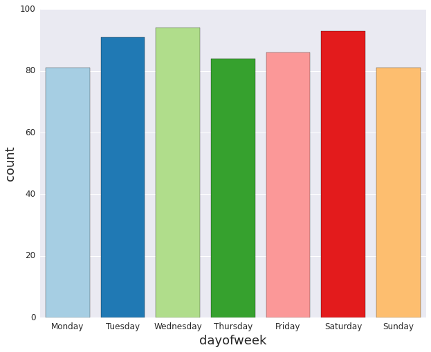

```python
import seaborn as sns
rc={"figure.figsize": (10, 8), 'axes.labelsize': 18, 'font.size': 18, 'axes.titlesize': 18, 'xtick.labelsize': 12, 'ytick.labelsize': 12}
sns.set(rc=rc)

sns.barplot(x='dayofweek', y='count', data=dow_df, palette="Paired",  x_order=weekdays)
```

There don't seem to be drastic differences in the number of incidents on each day of the week. I excepted Friday and Saturday to be the highest, but this sample shows Tuesday and Wednesday having just as many, if not more, incidents. My assumption of the number of incidents during the weekend may be true for nighttime hours. This barplot does not control for that.

### Number of Incidents by Date

Next, we want to see if there are any patterns in the number of incidents across days in the sample.

```python
# Group by
bydate = traffic.groupby('real_date')['real_date'].count()

# Put into a DataFrame
bydate_df = pd.DataFrame(bydate)

# Rename column
bydate_df.columns = ['count']

# Create a new column based on the day of the week
bydate_df['date'] = bydate_df.index

# Reset the index
bydate_df = bydate_df.reset_index(drop=True)
```

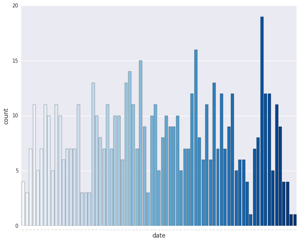

```python
rc={"figure.figsize": (10, 8), 'axes.labelsize': 12, 'font.size': 12, 'legend.fontsize': 12.0, 'axes.titlesize': 12, 'xtick.labelsize': 0}
sns.set(rc=rc)

bydate_plot = sns.barplot(x='date', y='count', data=bydate_df, palette="Blues")
```

### Traffic Indicents by Police District

Finally, we want to look at the number of incidents in each district.

```python
# Group by
pddistrict = traffic.groupby('pddistrict')['pddistrict'].count()
```

```python
# Put into a DataFrame
pd_df = pd.DataFrame(pddistrict)

# Rename column
pd_df.columns = ['count']

# Create a new column based on the day of the week
pd_df['pddistrict'] = pd_df.index

# Reset the index
pd_df = pd_df.reset_index(drop=True)
```

```python
# Capitalize the first letter of the weekday name
for entry in pd_df['pddistrict']:
    pd_df['pddistrict'] = pd_df['pddistrict'].str.title()
```

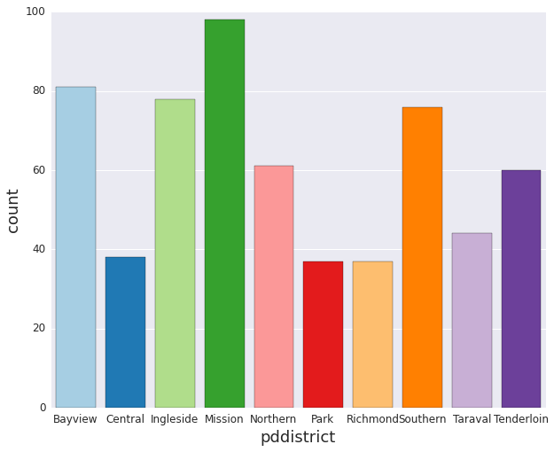

```python
import seaborn as sns
rc={"figure.figsize": (10, 8), 'axes.labelsize': 18, 'font.size': 18, 'axes.titlesize': 18, 'xtick.labelsize': 12, 'ytick.labelsize': 12}
sns.set(rc=rc)

sns.barplot(x='pddistrict', y='count', data=pd_df, palette="Paired")
```

While it's informative to know about where traffic incidents are occurring, it would be useful to have context. For example, does the Richmond area have very few traffic incidents because there are few drivers there or because it's a safe neighborhood? Geographic scale can also skew these results. If the Mission district is much larger than the other districts, the higher number of incidents may simply be due to that fact.

## For Mapping

Now, we use the data to create a map of traffic incidents in San Francisco.

### Create Geojson to Convert to JavaScript

```python
import json

geo_data = {
    'type': 'FeatureCollection',
    'features': []
}

for i in traffic.index:
    if traffic['y'][i]:

        # Each tweet is a GeoJSON "feature"
        feature = {
            'type': 'Feature',
            'geometry': {
                "type": "Point",
                "coordinates": [float(traffic['x'][i]), float(traffic['y'][i])]
            },

            # A feature's "properties" become attribute columns in GIS
            'properties': {
                'day': traffic['dayofweek'][i],
                'district': traffic['pddistrict'][i],
                'resolution': traffic['resolution'][i],
                'address': traffic['address'][i]
            }
        }

        # Add the feature into the GeoJSON wrapper
        geo_data['features'].append(feature)

with open('sftraffic.geojson', 'wb') as f:
    json.dump(geo_data, f, indent=2)

print len(geo_data['features']), 'geotagged entries saved to file'
```

```
610 geotagged entries saved to file
```